# Data Wrangling

Transforming data with `{dplyr}` and `{tidyr}`

**EPFL Extension School**

# Tidying and Transforming the data

## Wrangling: essential to tidy and transform the data

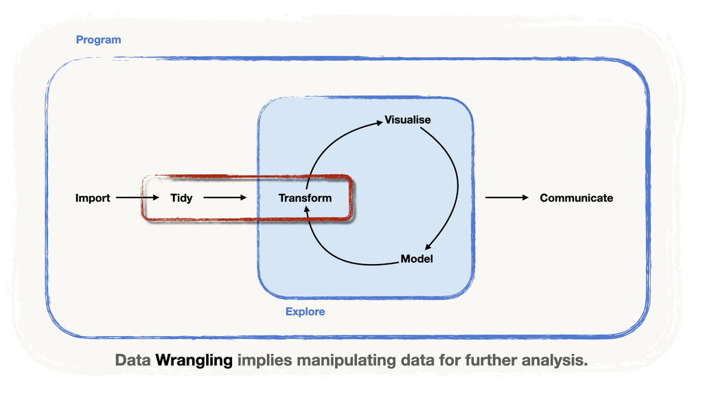

## Wrangling: essential to tidy and transform the data

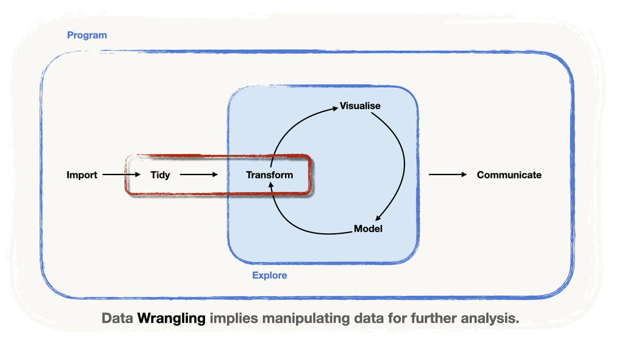

- **Tidy**: “cleaning” the data, making it ready for **analysis**
- Successively **Transform**: to refine our **understanding**

Both tasks require data manipulation, a.k.a. **data wrangling**.

## In this unit

- **The grammar of Data Manipulation**:
  - The `{tidyverse}` functions to wrangle data
  - Compute summary statistics:
    - in the dataset
    - by groups
- **Merge**: combine multiple datasets
- **Reshape**: reshape it to get insight or prepare for analysis

# A Grammar for Data Manipulation

## A Grammar for Data Manipulation

Because we are dealing with **tabular data**, the possible manipulations are a set of systematised tasks

## **Pick** columns from the table

👉 Create a dataset with only columns `C1` and `C3`

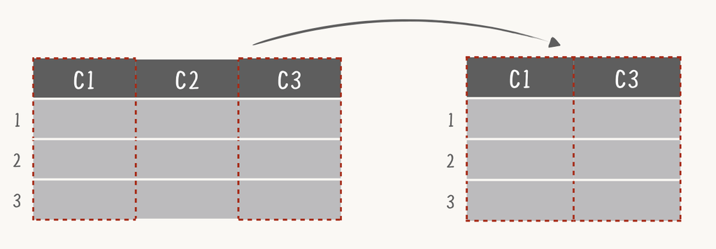

## **Transform** or **add** columns

👉 Add a column `C3 = 2*C1`

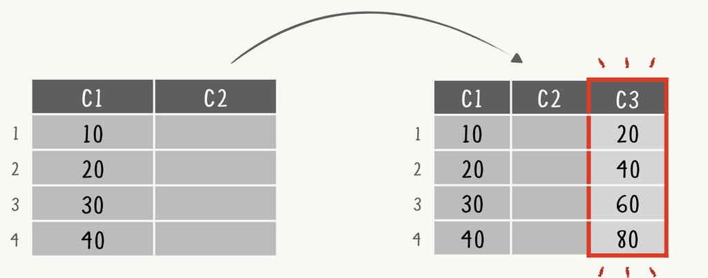

## **Subset rows** according to a value in a column

👉 Filter only the rows where `C1 == "DOG"`

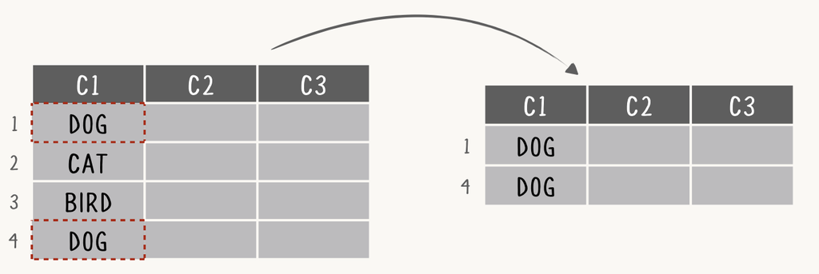

## **Order** the rows

👉 Arrange the rows according to the values of `C3`

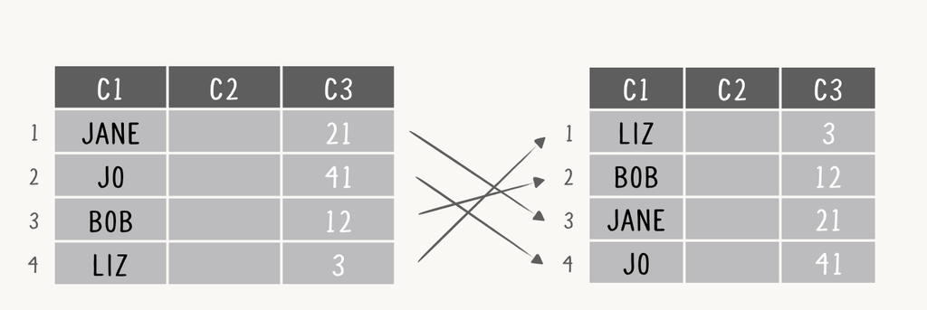

## Compute **summary statistics**

👉 The **sum of the `sales` column** over the whole dataset

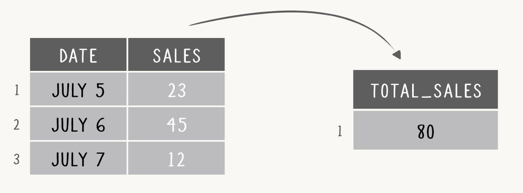

## Compute **grouped** **summary statistics**

👉 The sum of the `sales` **per `client`**.

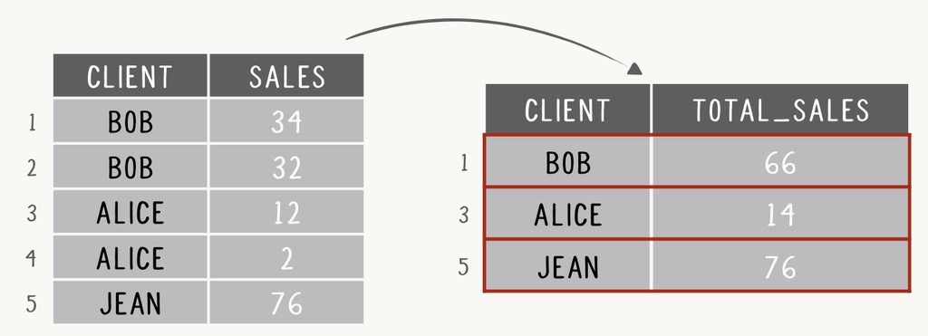

The `client` becomes the **grouping** factor.

## A Grammar for Data Manipulation

Because we are dealing with **tabular data**, the possible manipulations are a set of systematised tasks

| Use |
| --- |
| **pick a set of columns** from a `tibble` |
| **transform and add columns** to the `tibble` |
| **subsets rows** according to the values of a column |
| **order the rows** according to the values of a (set of) column(s) |
| **group** according to the values of a (set of) column(s) to perform calculations within the groups |
| create a new table containing **summary statistics** for a set of columns |

`{dplyr}` and `{tidyr}` are packages that provide a whole **grammar** to manipulate data.

## A Grammar for Data Manipulation

`{dplyr}` and `{tidyr}` are packages that provide a whole **grammar** to manipulate data.

[figure not shown]

These pliers will help us wrangle our data!

| Verb | Use |
| --- | --- |
| `select()` | **pick a set of columns** from a `tibble` |
| `mutate()` | **transform and add columns** to the `tibble` |
| `filter()` | **subsets rows** according to the values of a column |
| `arrange()` | **order the rows** according to the values of a (set of) column(s) |
| `group_by()` | **group** according to the values of a (set of) column(s) to perform calculations within the groups |
| `summarise()` | create a new `tibble` containing **summary statistics** for a set of columns |

## `{dplyr}`: Why *verbs*?

All the `{dplyr}` functions share a common structure

- Their **first argument** is the **dataset**.
- The **other arguments** relate to the **columns** on which we are operating

With the **pipe** operator(s), the commands can **chain like sentences**:

```r
select(dataset, column_1, column_2)

# Is equivalent to:

dataset %>% select(column_1, column_2)

# you see that it reads like a sentence!
```

# 🎾 Let’s practice wrangling in a real dataset

## 🎾 The WTA dataset

- `../data/wta_grand_slam_data.csv` contains the Women’s Tennis data.
- one row per **Grand Slam match**.

Use readr to import it:

```r
# 1. attach the package
library(readr)

# 2. assign data to an object
wta_data <-

  # 3. give the path through the pipe
  "../data/wta_grand_slam_data.csv" %>%

  # 4. use the function readr::read_csv()
  read_csv(

  # 5. set all columns as character
    col_types = cols(.default = "c")
    )

wta_data
```

```
# A tibble: 23,341 × 45
   year  tourney_id    tourney_name surface tourney_level tourney_date match_num
   <chr> <chr>         <chr>        <chr>   <chr>         <chr>        <chr>
 1 1968  1968-W-SL-AU… Australian … Grass   G             19680119     1
 2 1968  1968-W-SL-AU… Australian … Grass   G             19680119     2
 3 1968  1968-W-SL-AU… Australian … Grass   G             19680119     3
 4 1968  1968-W-SL-AU… Australian … Grass   G             19680119     4
 5 1968  1968-W-SL-AU… Australian … Grass   G             19680119     5
 6 1968  1968-W-SL-AU… Australian … Grass   G             19680119     6
 7 1968  1968-W-SL-AU… Australian … Grass   G             19680119     7
 8 1968  1968-W-SL-AU… Australian … Grass   G             19680119     8
 9 1968  1968-W-SL-AU… Australian … Grass   G             19680119     9
10 1968  1968-W-SL-AU… Australian … Grass   G             19680119     10
# ℹ 23,331 more rows
```

## 🎾 The columns of the WTA data

45 columns, grouped by **prefix**:

| column / prefix | Content |
| --- | --- |
| `year` | Year of the tournament the match took place |
| `tourney_*` | Information related to the tournament (`id`, `name`, `surface`, …) |
| `match_num` | Number of match **within a tournament** |
| `winner_*` | Information related to the winner of a given match (`id`, `name`, `hand`, …) |
| `loser_*` | Information related to the loser of a given match (`id`, `name`, `hand`, …) |

## 🔎 Inspecting Data

Right after importing, it’s always useful to **inspect** your dataset.

- **Which columns** are in the dataset
- Their **types** (numbers, text, dates, …)
- Where the **missing values** (`NA`) are
- and any other feature (or problem!) in the data

**Some inspecting tools**

- check the first rows with `head()` or `dplyr::slice_head()`
- get a summary of the contents with `dplyr::glimpse()`
- a visual representation with `visdat::vis_dat()`

## 🔎 Getting a `dplyr::glimpse()`

- One line per column: **name**, **type** and the first values

```r
glimpse(wta_data)
```

```
Rows: 23,341
Columns: 45
$ year               <chr> "1968", "1968", "1968", "1968", "1968", "1968", "19…
$ tourney_id         <chr> "1968-W-SL-AUS-01A-1968", "1968-W-SL-AUS-01A-1968",…
$ tourney_name       <chr> "Australian Championships", "Australian Championshi…
$ surface            <chr> "Grass", "Grass", "Grass", "Grass", "Grass", "Grass…
$ tourney_level      <chr> "G", "G", "G", "G", "G", "G", "G", "G", "G", "G", "…
$ tourney_date       <chr> "19680119", "19680119", "19680119", "19680119", "19…
$ match_num          <chr> "1", "2", "3", "4", "5", "6", "7", "8", "9", "10", …
$ winner_id          <chr> "200130", "200133", "200134", "200137", "200139", "…
$ winner_name        <chr> "Dorothy Whitely", "Eva De Jong", "Kerry Ballard", …
$ winner_hand        <chr> "U", "U", "U", "U", "L", "U", "U", "R", "U", "U", "…
$ winner_ht          <chr> NA, NA, NA, NA, NA, NA, NA, NA, NA, NA, NA, NA, NA,…
$ winner_ioc         <chr> "AUS", "NED", "AUS", "AUS", "INA", "AUS", "USA", "A…
$ winner_age         <chr> NA, NA, "18.0917180014", NA, "21.8918548939", NA, "…
```

[output cut: 32 more lines]

## 🔎 The full picture with `visdat::vis_dat()`

- **Colours**: the column **types** · **Grey**: **missing** values

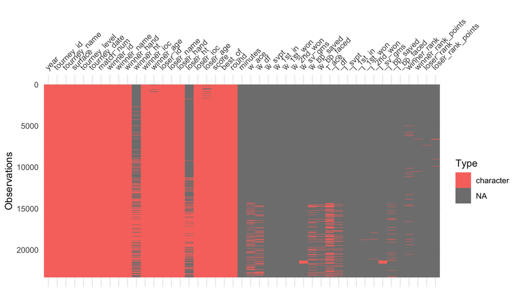

A bird’s-eye view of the WTA dataset using `visdat::vis_dat()`

```r
# 1. attach the package visdat
library(visdat)

wta_data %>%

# 2. use visdat::vis_dat()
  vis_dat(
    # 3. avoid warnings about large data
    warn_large_data = FALSE
    )
```

# The `{dplyr}` verbs in action

## Picking columns with `select()`

`dplyr::select()` to pick **one** or **several** columns by their name(s)

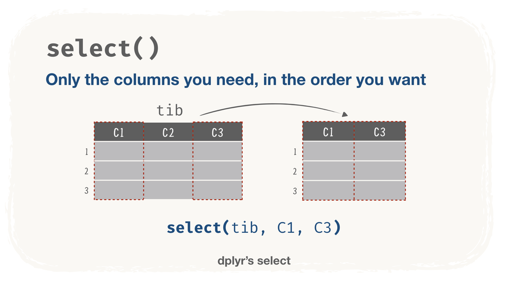

## Picking columns with `select()`

👉 use `select` to see who played against who over the years

```r
wta_data %>%
  select(year, winner_name, loser_name)
```

```
# A tibble: 23,341 × 3
   year  winner_name     loser_name
   <chr> <chr>           <chr>
 1 1968  Dorothy Whitely Judith Gohn
 2 1968  Eva De Jong     Kay Williams
 3 1968  Kerry Ballard   Lorraine Robinson
 4 1968  L Griffiths     Valerie Caulley
 5 1968  Lita Sugiarto   Sandra Hole
 6 1968  Beryl Jenkins   Wendy Gilchrist
 7 1968  Kathleen Harter Loris Butterfield
 8 1968  Margaret Court  Kerry Harris
 9 1968  Cynthia Doerner Geri Shepard
10 1968  Marilyn Tesch   Helen Sheedy
# ℹ 23,331 more rows
```

## Selection helpers

Instead of writing all the names, we pick the columns **whose names fulfil a condition**.

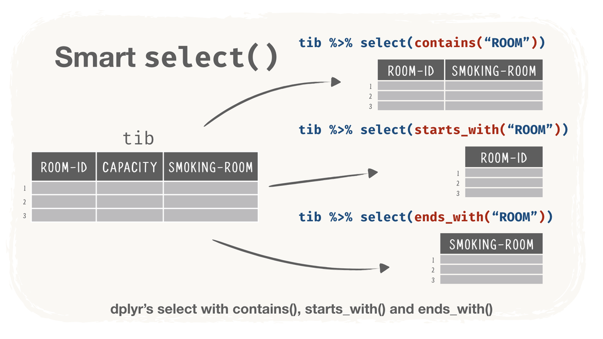

## Selection helpers

👉 `starts_with("winner")` or `starts_with("loser")` to get all the player info

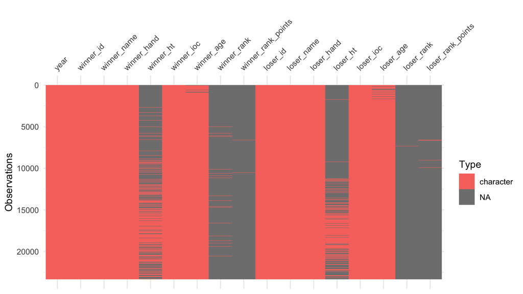

```r
wta_data %>%
  select(year,
    starts_with("winner"),
    starts_with("loser")) %>%
  vis_dat(warn_large_data = FALSE)
```

## Creating/Transforming columns with `mutate()`

`dplyr::mutate()` to **create** or **transform** columns

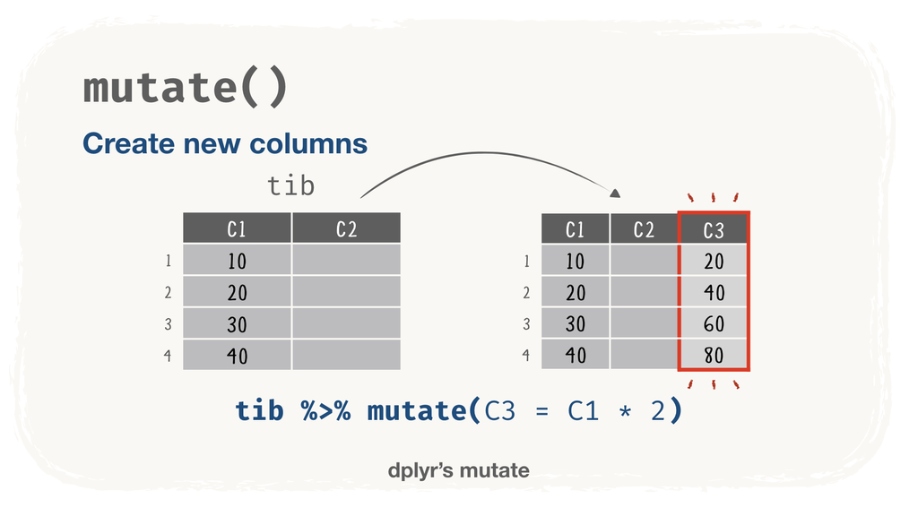

## Creating/Transforming columns with `mutate()`

👉 Let’s transform `year` → **number**, `tourney_date` → **date** (`ymd()` from `{lubridate}`)

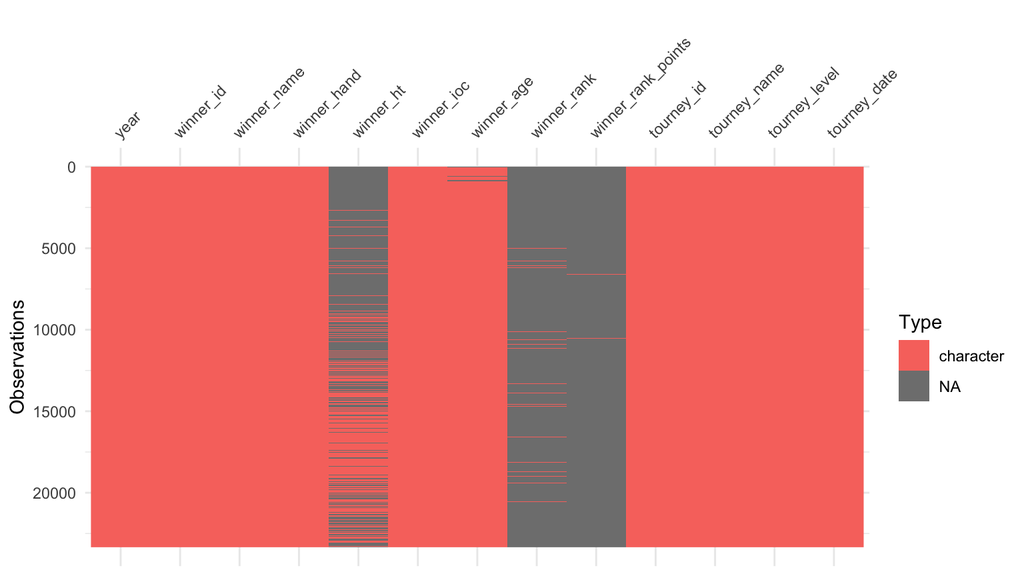

```r
wta_data %>%
  select(
    year,
    starts_with("winner"), starts_with("tourney")
    ) %>%
  vis_dat(warn_large_data = FALSE)
```

## Creating/Transforming columns with `mutate()`

👉 Let’s transform `year` → **number**, `tourney_date` → **date** (`ymd()` from `{lubridate}`)

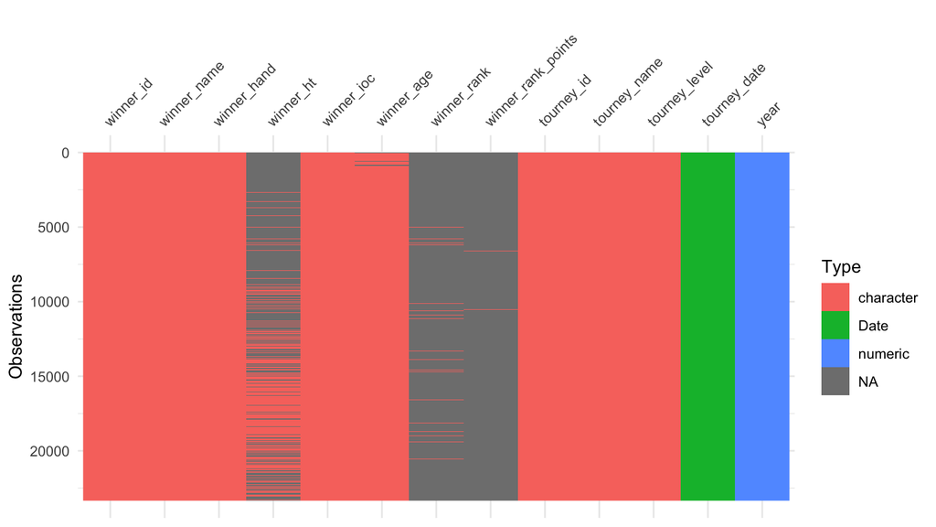

```r
# 1. attach lubridate
library(lubridate)

wta_data %>%
  select(
    year,
    starts_with("winner"), starts_with("tourney")
    ) %>%

# 2. make the changes
  mutate(
    year = as.numeric(year),
    tourney_date = ymd(tourney_date)
    ) %>%

  vis_dat(warn_large_data = FALSE)
```

## ⚠️ Making the changes permanent

Applying `mutate()` by itself **does not change the dataset**.

👉 The following pipe **does not modify** the contents of `data` **permanently**.

```r
data %>%
  mutate(...)
```

In R you need to **(re-)assign** to make your changes perennial

👉 The following pipe **does**

```r
data <-
  data %>%
  mutate(...)
```

## ⚠️ Making the changes permanent

👉 Let’s keep the new column types: we **re-assign** the result to `wta_data`

```r
wta_data <-
  wta_data %>%
  mutate(
    year = as.numeric(year),
    tourney_date = ymd(tourney_date))
```

Now the changes are there for the rest of the unit:

```r
wta_data %>%
  select(year, tourney_date) %>%
  slice_head(n = 3)
```

```
# A tibble: 3 × 2
   year tourney_date
  <dbl> <date>
1  1968 1968-01-19
2  1968 1968-01-19
3  1968 1968-01-19
```

## Sub-setting rows with `filter()`

`dplyr::filter()` to keep the rows that **fulfil a logical condition**

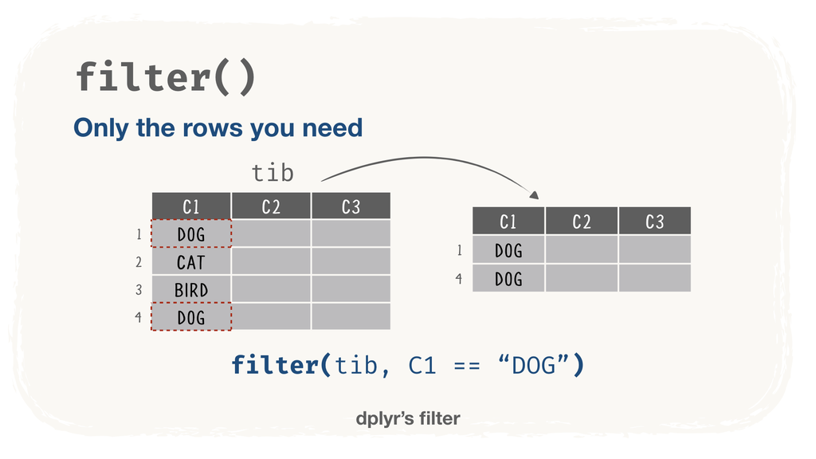

## Sub-setting rows with `filter()`

👉 Keep only the matches won by Serena Williams

```r
wta_data %>%
  select(year, tourney_name, winner_name) %>%
  filter(winner_name == "Serena Williams")
```

```
# A tibble: 362 × 3
    year tourney_name    winner_name
   <dbl> <chr>           <chr>
 1  1998 Australian Open Serena Williams
 2  1998 Roland Garros   Serena Williams
 3  1998 Roland Garros   Serena Williams
 4  1998 Roland Garros   Serena Williams
 5  1998 Wimbledon       Serena Williams
 6  1998 Wimbledon       Serena Williams
 7  1998 US Open         Serena Williams
 8  1998 US Open         Serena Williams
 9  1999 Australian Open Serena Williams
10  1999 Australian Open Serena Williams
# ℹ 352 more rows
```

⚠️ Comparison uses the **double** equal sign `==`. The single `=` assigns, e.g. in `mutate()`.

## `filter()` with several conditions

👉 Serena’s wins at the Australian tournaments: **all** conditions must hold

```r
# 1. attach stringr
library(stringr)

wta_data %>%
  filter(
    # 2. first condition: the winner
    winner_name == "Serena Williams",
    # 3. second condition: the tournament
    str_detect(
      tourney_name,
      pattern = "Australian")) %>%

# 4. keep a few columns
  select(year, tourney_name, winner_name)
```

```
# A tibble: 92 × 3
    year tourney_name    winner_name
   <dbl> <chr>           <chr>
 1  1998 Australian Open Serena Williams
 2  1999 Australian Open Serena Williams
 3  1999 Australian Open Serena Williams
 4  2000 Australian Open Serena Williams
 5  2000 Australian Open Serena Williams
 6  2000 Australian Open Serena Williams
 7  2001 Australian Open Serena Williams
 8  2001 Australian Open Serena Williams
 9  2001 Australian Open Serena Williams
10  2001 Australian Open Serena Williams
# ℹ 82 more rows
```

Other conditions: `<`, `>=`, `&`, `|`, `%in%`. The handout has the full list.

## Sort observations with `arrange()`

`dplyr::arrange()` to **order the rows** by the values of some columns

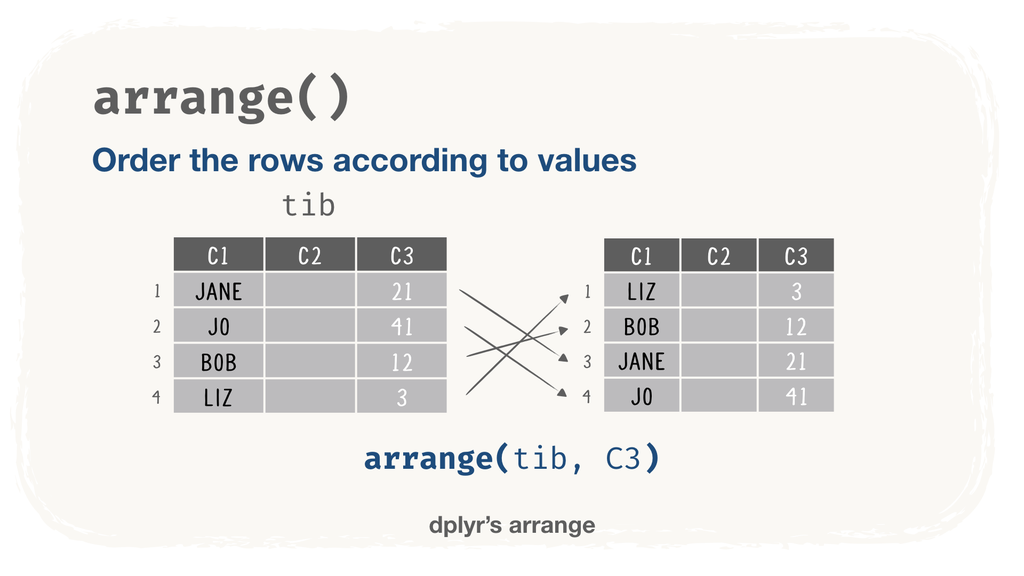

## Sort observations with `arrange()`

👉 Which matches are the oldest in the dataset?

```r
wta_data %>%
  select(year, winner_name, tourney_name) %>%
  arrange(year)
```

```
# A tibble: 23,341 × 3
    year winner_name     tourney_name
   <dbl> <chr>           <chr>
 1  1968 Dorothy Whitely Australian Championships
 2  1968 Eva De Jong     Australian Championships
 3  1968 Kerry Ballard   Australian Championships
 4  1968 L Griffiths     Australian Championships
 5  1968 Lita Sugiarto   Australian Championships
 6  1968 Beryl Jenkins   Australian Championships
 7  1968 Kathleen Harter Australian Championships
 8  1968 Margaret Court  Australian Championships
 9  1968 Cynthia Doerner Australian Championships
10  1968 Marilyn Tesch   Australian Championships
# ℹ 23,331 more rows
```

## `arrange()`: several columns

👉 Sort by **year**, then by **winner** within each year

```r
wta_data %>%
  select(year, winner_name, tourney_name) %>%
  arrange(year, winner_name)
```

```
# A tibble: 23,341 × 3
    year winner_name tourney_name
   <dbl> <chr>       <chr>
 1  1968 Ada Bakker  Wimbledon
 2  1968 Alice Tym   US Open
 3  1968 Ann Jones   Roland Garros
 4  1968 Ann Jones   Roland Garros
 5  1968 Ann Jones   Roland Garros
 6  1968 Ann Jones   Roland Garros
 7  1968 Ann Jones   Roland Garros
 8  1968 Ann Jones   Wimbledon
 9  1968 Ann Jones   Wimbledon
10  1968 Ann Jones   Wimbledon
# ℹ 23,331 more rows
```

## `arrange()`: several columns

👉 `desc()` reverses the order: winners from Z to A within each year

```r
wta_data %>%
  select(year, winner_name, tourney_name) %>%
  arrange(year, desc(winner_name))
```

```
# A tibble: 23,341 × 3
    year winner_name       tourney_name
   <dbl> <chr>             <chr>
 1  1968 Yveline Boy       Australian Championships
 2  1968 Winnie Wooldridge Wimbledon
 3  1968 Winnie Wooldridge Wimbledon
 4  1968 Wendy Overton     US Open
 5  1968 Wendy Overton     US Open
 6  1968 Vlasta Kodesova   Roland Garros
 7  1968 Vlasta Kodesova   Roland Garros
 8  1968 Vlasta Kodesova   Roland Garros
 9  1968 Virginia Wade     US Open
10  1968 Virginia Wade     US Open
# ℹ 23,331 more rows
```

## Exercise Time!

**Time to work!**

Open the exercise notebook `_exercises/exercise-notebook.qmd` and do **Exercise 2**. See you there!

## Producing summary statistics with `summarise()`

`dplyr::summarise()` creates a **new table** with **summaries** of the columns

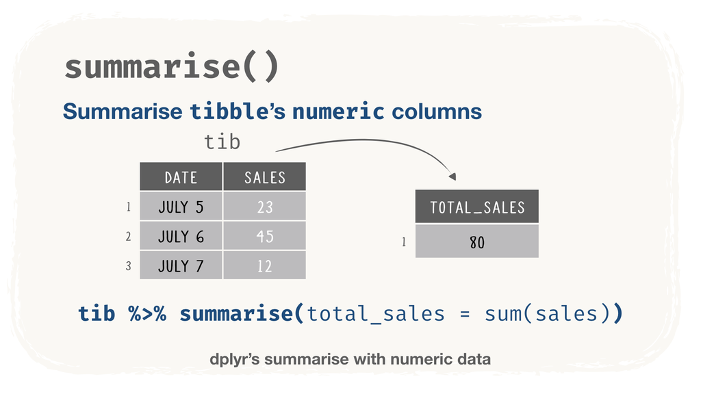

## Producing summary statistics with `summarise()`

👉 How many Australian matches did Serena win? `n()` **counts the rows**

```r
wta_data %>%

# 1. keep Serena's Australian wins
  filter(
    winner_name == "Serena Williams",
    str_detect(
      tourney_name,
      pattern = "Australian")) %>%

# 2. count the rows
  summarise(number_of_wins = n())
```

```
# A tibble: 1 × 1
  number_of_wins
           <int>
1             92
```

## Other summary functions

| Summary Statistic | Functions |
| --- | --- |
| Center | `mean()`, `median()` |
| Spread | `sd()`, `IQR()`, `mad()` |
| Range | `min()`, `max()`, `quantile()` |
| Total | `sum()` |
| Position | `first()`, `last()`, `nth()` |
| Count | `n()`, `n_distinct()` |
| Logical | `any()`, `all()` |

## Creating groups with `group_by()`

`dplyr::group_by()` **groups** the rows by the values of one or more columns

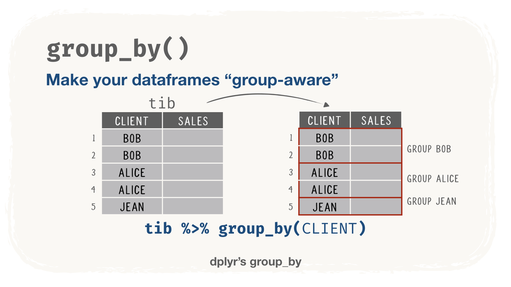

## Creating groups with `group_by()`

👉 Group the matches by winner, and look for the `# Groups:` line in the printout

```r
wta_data %>%
  group_by(winner_name)
```

```
# A tibble: 23,341 × 45
# Groups:   winner_name [1,331]
    year tourney_id    tourney_name surface tourney_level tourney_date match_num
   <dbl> <chr>         <chr>        <chr>   <chr>         <date>       <chr>
 1  1968 1968-W-SL-AU… Australian … Grass   G             1968-01-19   1
 2  1968 1968-W-SL-AU… Australian … Grass   G             1968-01-19   2
 3  1968 1968-W-SL-AU… Australian … Grass   G             1968-01-19   3
 4  1968 1968-W-SL-AU… Australian … Grass   G             1968-01-19   4
 5  1968 1968-W-SL-AU… Australian … Grass   G             1968-01-19   5
 6  1968 1968-W-SL-AU… Australian … Grass   G             1968-01-19   6
 7  1968 1968-W-SL-AU… Australian … Grass   G             1968-01-19   7
 8  1968 1968-W-SL-AU… Australian … Grass   G             1968-01-19   8
 9  1968 1968-W-SL-AU… Australian … Grass   G             1968-01-19   9
10  1968 1968-W-SL-AU… Australian … Grass   G             1968-01-19   10
# ℹ 23,331 more rows
```

## `group_by()` `%>%` `summarise()`

`summarise()` after `group_by()` gives **one row per group**

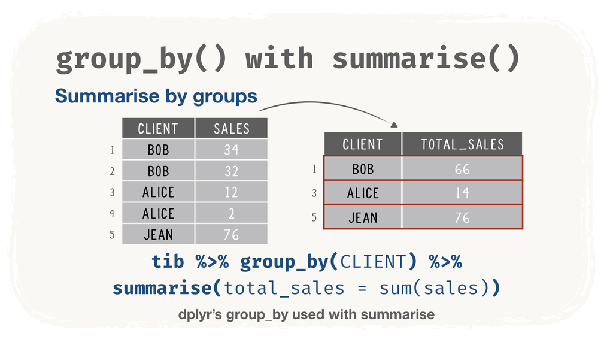

## `group_by()` `%>%` `summarise()`

👉 The number of wins of **every** player

```r
wta_data %>%
  group_by(winner_name) %>%
  summarise(
    number_of_wins = n(),
    .groups = "drop")
```

```
# A tibble: 1,331 × 2
   winner_name             number_of_wins
   <chr>                            <int>
 1 Abigail Spears                       2
 2 Ada Bakker                           3
 3 Adriana Gersi                       11
 4 Adriana Serra Zanetti               13
 5 Adriana Villagran Reami              8
 6 Adrienne Avis                        1
 7 Agnes Szavay                        18
 8 Agnieszka Radwanska                125
 9 Ahsha Rolle                          2
10 Ai Sugiyama                         84
# ℹ 1,321 more rows
```

## `group_by()` `%>%` `summarise()`

👉 So, **who won the most**? Sort the result with `arrange()` and `desc()`

```r
wta_data %>%
  group_by(winner_name) %>%
  summarise(
    number_of_wins = n(),
    .groups = "drop") %>%
  arrange(desc(number_of_wins))
```

```
# A tibble: 1,331 × 2
   winner_name             number_of_wins
   <chr>                            <int>
 1 Serena Williams                    362
 2 Martina Navratilova                306
 3 Chris Evert                        299
 4 Steffi Graf                        280
 5 Venus Williams                     271
 6 Arantxa Sanchez Vicario            212
 7 Lindsay Davenport                  198
 8 Maria Sharapova                    198
 9 Monica Seles                       181
10 Conchita Martinez                  174
# ℹ 1,321 more rows
```

## Grouping by several columns

👉 The wins of **each player** in **each tournament**

```r
wta_data %>%
  group_by(winner_name, tourney_name) %>%
  summarise(
    number_of_wins = n(),
    .groups = "drop")
```

```
# A tibble: 3,540 × 3
   winner_name             tourney_name    number_of_wins
   <chr>                   <chr>                    <int>
 1 Abigail Spears          Australian Open              2
 2 Ada Bakker              Wimbledon                    3
 3 Adriana Gersi           Australian Open              4
 4 Adriana Gersi           Roland Garros                3
 5 Adriana Gersi           US Open                      4
 6 Adriana Serra Zanetti   Australian Open              6
 7 Adriana Serra Zanetti   Roland Garros                6
 8 Adriana Serra Zanetti   Wimbledon                    1
 9 Adriana Villagran Reami Roland Garros                4
10 Adriana Villagran Reami US Open                      1
# ℹ 3,530 more rows
```

## Exercise Time!

**Time to work!**

Open the exercise notebook `_exercises/exercise-notebook.qmd` and do **Exercise 3**. See you there!

# Merging Data

## Binding and joining

Real data is often split into **several linked tables**: we **merge** them to get the information we need

- **Stack** tables with the same columns: `bind_rows()`
- **Attach** tables that share a column: the `*_join()` verbs

## Three toy datasets

```r
data_1 <- tibble(id = 1:3, var_1 = c(15, 13, 39))
data_2 <- tibble(id = c(4, 5), var_1 = 10)
data_3 <- tibble(id = 1:3, var_2 = c(10, 12, 14), var_3 = c(45, 20, 2))
```

```r
data_1
```

```
# A tibble: 3 × 2
     id var_1
  <int> <dbl>
1     1    15
2     2    13
3     3    39
```

```r
data_2
```

```
# A tibble: 2 × 2
     id var_1
  <dbl> <dbl>
1     4    10
2     5    10
```

```r
data_3
```

```
# A tibble: 3 × 3
     id var_2 var_3
  <int> <dbl> <dbl>
1     1    10    45
2     2    12    20
3     3    14     2
```

## *Stacking* data sets with `bind_rows()`

👉 `data_1` and `data_2`: **same columns**, **different rows**

```r
data_1 %>%
  bind_rows(data_2)
```

```
# A tibble: 5 × 2
     id var_1
  <dbl> <dbl>
1     1    15
2     2    13
3     3    39
4     4    10
5     5    10
```

The left-hand side of the pipe goes **on top**

## *Joining* data sets with `left_join()`

`dplyr::left_join()` attaches columns, matching the rows by a **joining key**

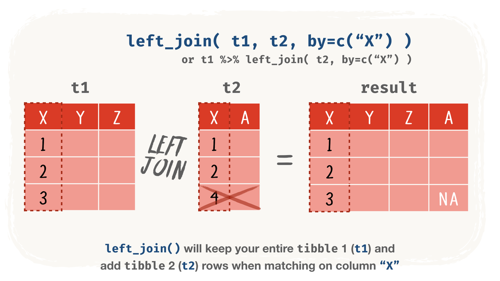

## How `left_join()` works

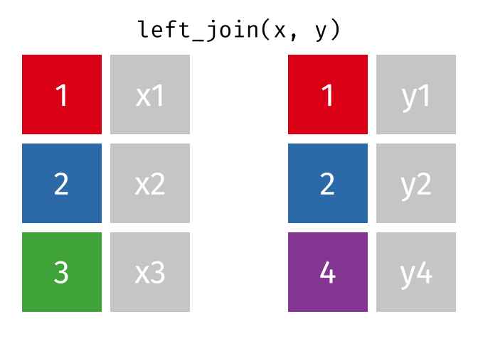

**Source:** [Garrick Aden-Buie’s](https://github.com/gadenbuie/tidyexplain) Tidy Animated Verbs

Why “left”? It **keeps all the rows of the first** (*left-hand side*) **tibble**

## `left_join()` with a joining key

👉 Stack `data_1` and `data_2`, then attach the columns of `data_3`

```r
data_1 %>%

# 1. stack the first two tables
  bind_rows(data_2) %>%

# 2. attach data_3, matching on id
  left_join(data_3, by = "id")
```

```
# A tibble: 5 × 4
     id var_1 var_2 var_3
  <dbl> <dbl> <dbl> <dbl>
1     1    15    10    45
2     2    13    12    20
3     3    39    14     2
4     4    10    NA    NA
5     5    10    NA    NA
```

`data_3` has no `id` 4 or 5: their new columns are `NA`.

## Rows of the second table without a match

👉 `data_4`: `data_3` plus a row with `id = 8`, which isn’t in `data_1`

```r
data_4 <-
  bind_rows(
    data_3,
    tibble(id = 8, var_2 = 3, var_3 = 12))
data_4
```

```
# A tibble: 4 × 3
     id var_2 var_3
  <dbl> <dbl> <dbl>
1     1    10    45
2     2    12    20
3     3    14     2
4     8     3    12
```

```r
data_1 %>%
  left_join(data_4, by = "id")
```

```
# A tibble: 3 × 4
     id var_1 var_2 var_3
  <dbl> <dbl> <dbl> <dbl>
1     1    15    10    45
2     2    13    12    20
3     3    39    14     2
```

`id` 8 is gone: only the rows of the **first** table are kept.

# Pivoting Data

## Long vs wide tables

- **Long**: every column is a *variable* → for **analysis** (computations, plots)
- **Wide**: some columns are named after *values* of a variable → for **display** in reports

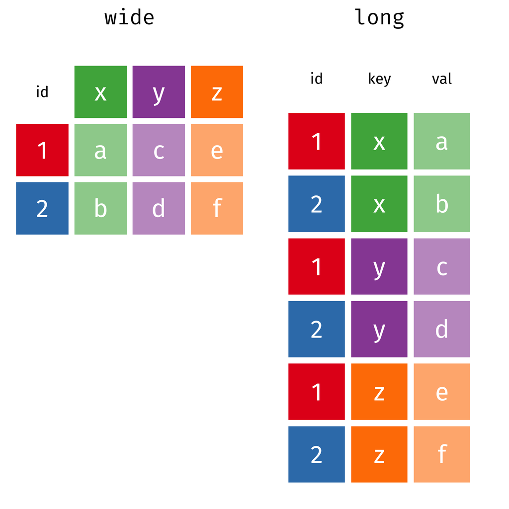

Wide-format vs. long-format data

## `{tidyr}`: `pivot_longer()` and `pivot_wider()`

[figure not shown]

The brooms of `{tidyr}` will help us tidy our data!

Source: [Garrick Aden-Buie’s](https://github.com/gadenbuie/tidyexplain) Tidy Animated Verbs, modified by [Mara Averick](https://twitter.com/dataandme)

## Pivoting into long-form with `pivot_longer()`

`tidyr::pivot_longer()` converts **columns to rows**

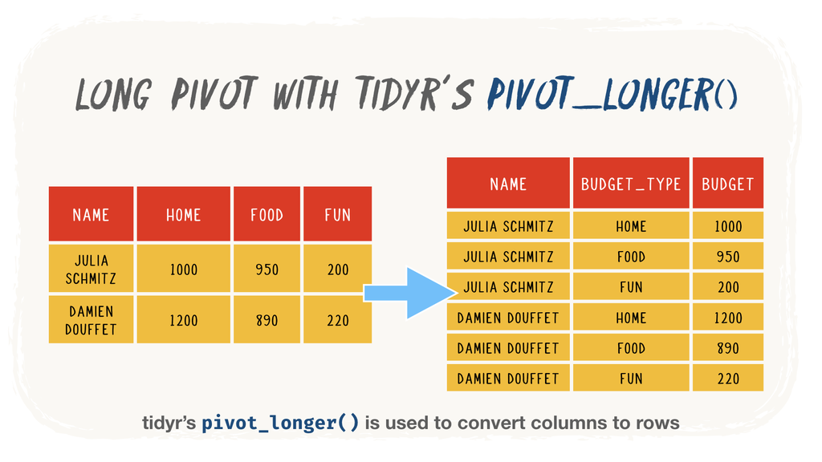

## How to write `pivot_longer()`

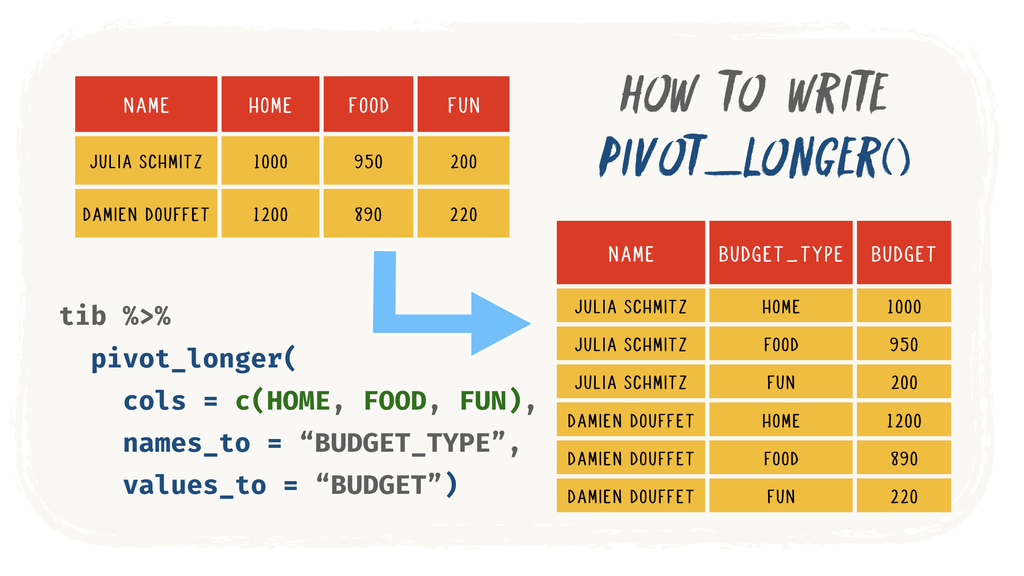

## `pivot_longer()`: `cols`

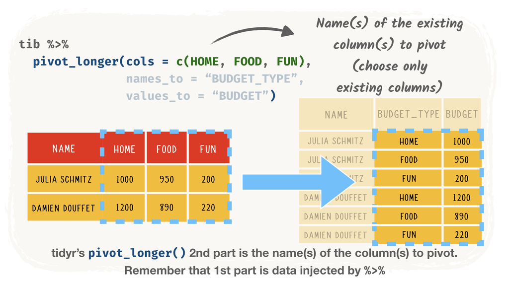

## `pivot_longer()`: `names_to`

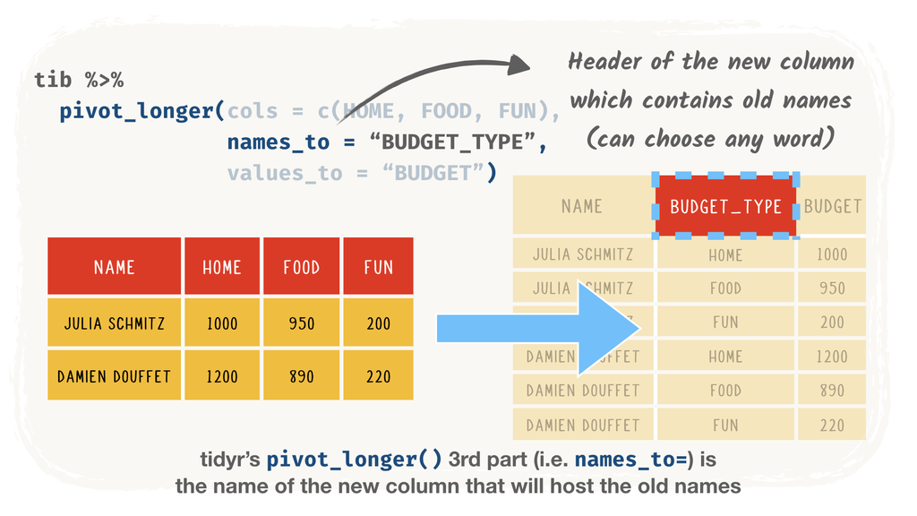

## `pivot_longer()`: `values_to`

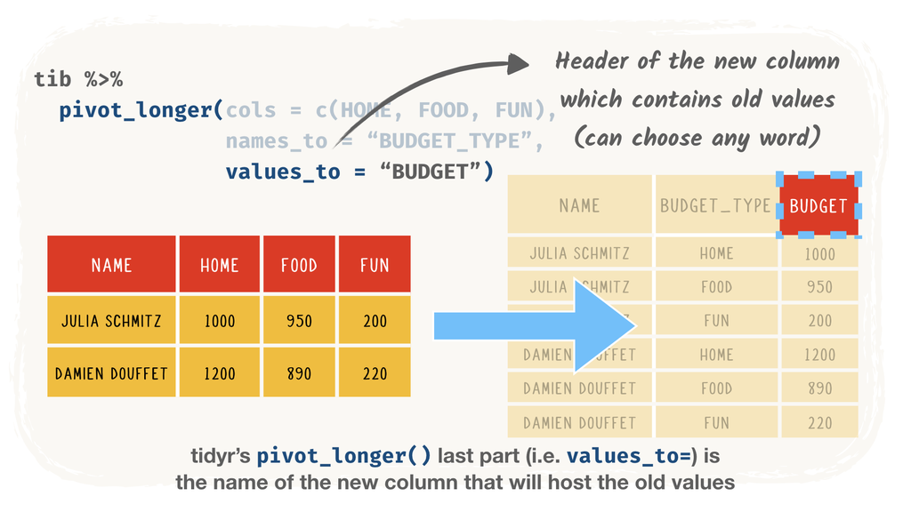

## `pivot_longer()`: recap

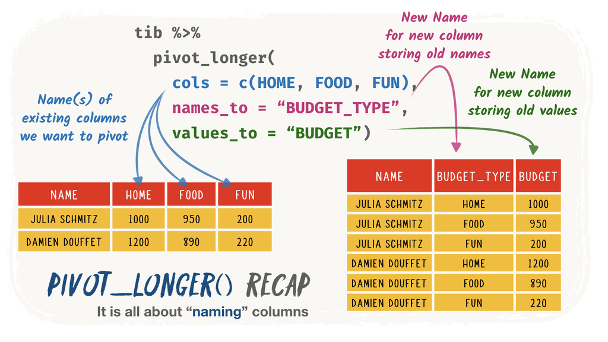

## From wide to long

👉 Prototypes measured at 3 timepoints: one column per timepoint

```r
data_5_wide <-
  tibble(
    prototype = 1:5 ,
    t_1 = c(12,1,3,4,5),
    t_2 = c(13,0,3,6,3),
    t_3 = c(14,-1,3,8,1))
data_5_wide
```

```
# A tibble: 5 × 4
  prototype   t_1   t_2   t_3
      <int> <dbl> <dbl> <dbl>
1         1    12    13    14
2         2     1     0    -1
3         3     3     3     3
4         4     4     6     8
5         5     5     3     1
```

## From wide to long

👉 One `timepoint` column and one `performance` column

```r
data_5_long <-
  data_5_wide %>%
  pivot_longer(
    # 1. all the columns but prototype
    cols = -c(prototype),
    # 2. where the old names go
    names_to = "timepoint",
    # 3. where the values go
    values_to = "performance"
  )

data_5_long
```

```
# A tibble: 15 × 3
   prototype timepoint performance
       <int> <chr>           <dbl>
 1         1 t_1                12
 2         1 t_2                13
 3         1 t_3                14
 4         2 t_1                 1
 5         2 t_2                 0
 6         2 t_3                -1
 7         3 t_1                 3
 8         3 t_2                 3
 9         3 t_3                 3
10         4 t_1                 4
11         4 t_2                 6
12         4 t_3                 8
13         5 t_1                 5
14         5 t_2                 3
15         5 t_3                 1
```

## Cleaner timepoints

👉 Remove the `t_` prefix, and make the timepoints **numbers**

```r
data_5_long <-
  data_5_wide %>%
  pivot_longer(
    cols = -c(prototype),
    names_to = "timepoint",
    values_to = "performance",
    # 1. remove the `t_` prefix
    names_prefix = "t_",
    # 2. make the timepoints integers
    names_transform = list(
      timepoint = as.integer)
  )

data_5_long
```

```
# A tibble: 15 × 3
   prototype timepoint performance
       <int>     <int>       <dbl>
 1         1         1          12
 2         1         2          13
 3         1         3          14
 4         2         1           1
 5         2         2           0
 6         2         3          -1
 7         3         1           3
 8         3         2           3
 9         3         3           3
10         4         1           4
11         4         2           6
12         4         3           8
13         5         1           5
14         5         2           3
15         5         3           1
```